# Section 1.3: Converting DFA’s to Regular Expressions

# Are Regular Expressions the same as regular languages?

## So far…

- **Regular Languages** are languages that are recognized by DFA’s
- We have proved:
  - DFA’s can simulate NFA’s, so we can use NFA’s instead.
  - Regular languages are closed under **regular operations** $\cup$, $\circ$, $*$
  - Lemma 1.55. If a language is described by a regular expression, then it is a regular language.

Today we consider the converse.

## Regular Language $\Rightarrow$ Regular Expression

Lemma 1.60. If a language is regular, then there is a regular expression that describes it.

Outline of proof:

- If a language is regular, there is a DFA that recognizes it.
- Convert this DFA into a GNFA.
- Reduce the number of states in the GNFA until you only have 2 left.
- A 2-state GNFA is a regular expression. Done.

## GNFA: definition

A *generalized nondeterministic finite automaton* is a 5-tuple $(Q, \Sigma, \delta, q_\text{start}, q_\text{accept})$, where

1. $Q$ is a finite set of states,
2. $\Sigma$ is the input alphabet,
3. $\delta: (Q \setminus \{q_\text{accept}\})\times (Q \setminus \{q_\text{start}\}) \longrightarrow \mathcal{R}$ is the transition function, where $\mathcal{R}$ is the set of all regular expressions.
4. $q_\text{start}$ is the start state, to which no arrow points.
5. $q_\text{accept}$ is the lone accept state, which has no arrows out.

## Given DFA, make equivalent GNFA

Add a start state, and consolidate the accept states.

## Reduction step

Idea: Choose a state to delete, then modify the affected arrows.

(e.g., Prework #5)

## Reduce until only two states are left

# Using the proof to construct regular expressions from DFA’s

## First: Convert the given DFA into a GNFA

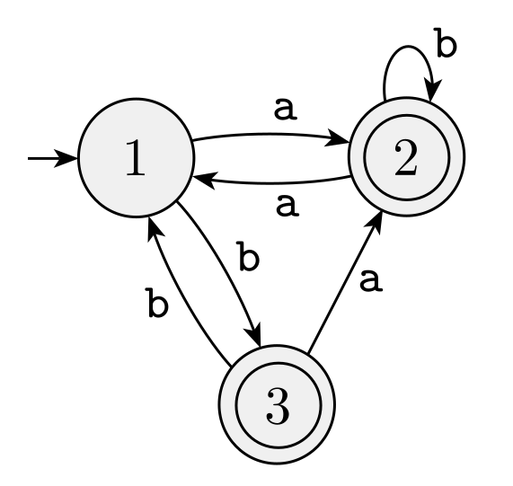

## Next: Delete State 1 and repair

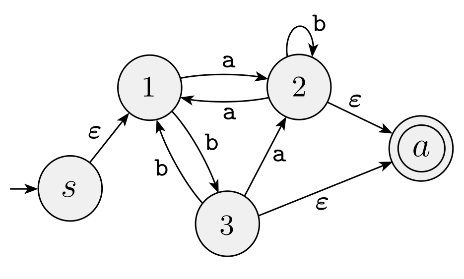

## Next: Delete State 2 and repair

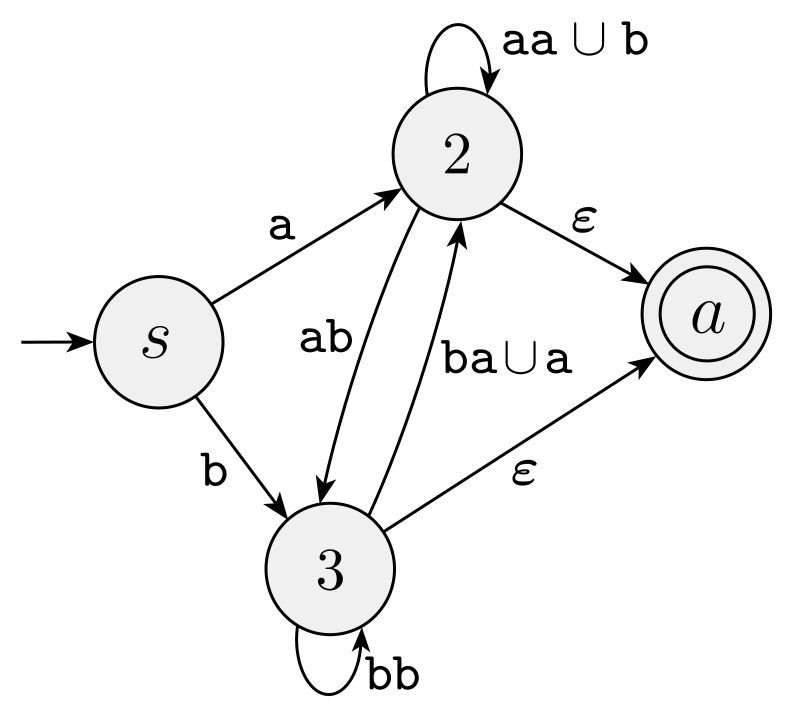

## Finally: Delete State 3 and repair

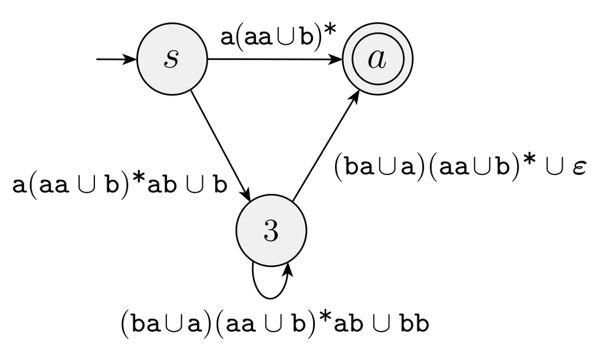

## Final result: regular expression

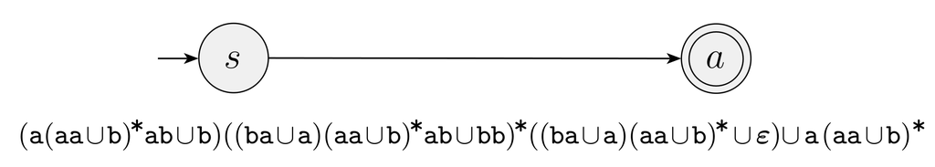